```python
%run talktools
```

# Plotly collaborative, interactive and online plotting with $\TeX$

## What is Plotly?

Plotly is an **online** analytics and data visualization tool.

```python
from IPython.display import IFrame

IFrame("https://plot.ly/~Dreamshot/407", width="900px", height='500px')
```

[interactive chart not shown]

## Why is Plotly at TUG 2014?

- You can use $\TeX$ symbols to annotate Plotly graphs, (using the [MathJax](http://www.mathjax.org/) display engine)

```python
from IPython.display import IFrame

IFrame("https://plot.ly/~PlotBot/3", width="900px", height='500px')
```

[interactive chart not shown]

## But really ... Why is Plotly at TUG 2014?

#### ... Philosophy

$\TeX$ provides a system that gives exactly the same results on all computers

- $\TeX$ is **cross-operating system**

$\TeX$ allows anybody to produce high-quality documents efficiently

- $\TeX$ is a **free** and **cross-text editor** platform

Plotly applies the same core principles to graphs

- Plotly is **free**, **cross-operating system** and **cross-scientific computing language**

### Collaboration in data-intensive fields sometimes feels like this:

[figure not shown]

Plotly solves this collaboration (i.e. reproducibility) problem:

- Plotly graphs are **closely connected to their underlying data** (more later)
- Plotly graphs are **stored in the cloud**
- Plotly provides a **common graphing platform** for Python, MATLAB, R, Node.js, Julia and Excel users.

### A Plotly graph made in Python

```python
from IPython.display import IFrame

IFrame("https://plot.ly/python/histograms/#Overlaid-Histgram", width="1100px", height='520px')
```

[interactive chart not shown]

### The same Plotly graph, now made in MATLAB

```python
from IPython.display import IFrame

IFrame("https://plot.ly/matlab/histograms/#Overlaid-Histgram", width="1100px", height='520px')
```

[interactive chart not shown]

### ... and again the same Plotly graph, now made in R

```python
from IPython.display import IFrame

IFrame("https://plot.ly/r/histograms/#Overlaid-Histgram", width="1100px", height='520px')
```

[interactive chart not shown]

### What if I already have plot-generating code written?

That's OK.

Our libraries come with **figure converters** allowing

- [MATLAB](https://plot.ly/matlab/),
- [matplotlib](https://plot.ly/matplotlib/) and
- [ggplot2](https://plot.ly/ggplot2/)

figures to be converted to Plotly figures with one line of code!

```python
from IPython.display import IFrame

IFrame("https://plot.ly/matplotlib/", width="1100px", height='520px')
```

[interactive chart not shown]

### How to make Plotly graph using our web app

- Have some [data](http://en.wikipedia.org/wiki/Portland,_Oregon#Demographics) to plot
- Go to plot.ly

### Plotly rhymes with collaboration and reproducibility

Plotly allows you to **retrieve** a figure's underlying JSON object!

For example, in Python:

```python
import plotly.plotly as py

fig = py.get_figure("https://plot.ly/~etpinard/450")

fig
```

```
{'data': [{'name': u'Pop.',
   'type': u'scatter',
   'x': [u'1860',
    u'1870',
    u'1880',
    u'1890',
    u'1900',
    u'1910',
    u'1920',
    u'1930',
    u'1940',
    u'1950',
    u'1960',
    u'1970',
    u'1980',
    u'1990',
    u'2000',
    u'2010',
    u'2013'],
   'y': [u'2,874',
    u'8,293',
    u'17,577',
    u'46,385',
    u'90,426',
    u'207,214',
    u'258,288',
    u'301,815',
    u'305,394',
    u'373,628',
    u'372,676',
    u'382,619',
    u'366,383',
    u'437,319',
    u'529,121',
    u'583,776',
    u'609,456']},
  {'line': {'color': u'rgb(255, 127, 14)', 'width': 6},
   'name': u'Pop. - fit',
   'opacity': 0.5,
   'type': u'scatter',
```

[output cut: 209 more lines]

```
   'showline': False,
   'showticklabels': True,
   'tick0': 0,
   'tickangle': u'auto',
   'tickcolor': u'#444',
   'tickfont': {'color': u'', 'family': u'', 'size': 0},
   'ticklen': 5,
   'ticks': u'',
   'tickwidth': 1,
   'title': u'Pop.',
   'titlefont': {'color': u'', 'family': u'', 'size': 0},
   'type': u'-',
   'zeroline': True,
   'zerolinecolor': u'#444',
   'zerolinewidth': 1}}}
```

### Remake this plot, with a few modifications

```python
import plotly.plotly as py
fig = py.get_figure("https://plot.ly/~etpinard/450")  # as in last slide

# Modify the title
fig['layout'].update(title="The Historical Population of Portland, OR")

# Modify the y-axis label
fig['layout']['yaxis'].update(title="Population")

# Plots the data with marker points (not line)
fig['data'][0].update(mode='markers')


# Re-generate plot, get a unique URL
py.plot(fig, filename="tug-conf-example")
```

```
u'https://plot.ly/~etpinard/451'
```

Go to plot's URL (or use `py.iplot()` to embed plot in IPython notebook)

### Save a copy on your computer

```python
import plotly.plotly as py

py.image.save_as(fig, filename='test.png')
```

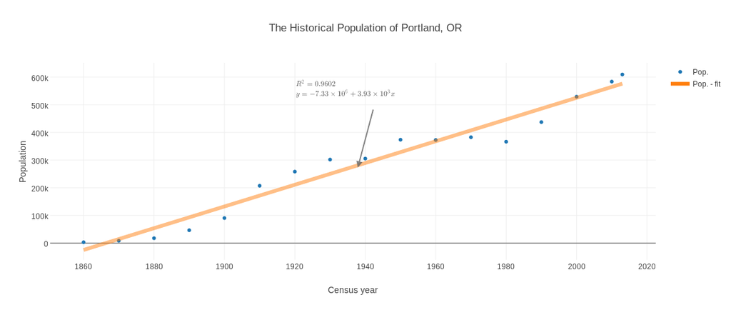

```python
from IPython.display import Image

Image("test.png")
```

## Moreover, Plotly

- is also a social network (with a twitter-like *feed* of figures and [commenting](https://plot.ly/~etpinard/25) on each graphs)
- allows users to make *private* figures (kind of like github, see our plans)
- allows users to make *streaming* plots (e.g. a never-ending double pendulum simulation: [graph](https://plot.ly/~streaming-demos/4) and [code](http://nbviewer.ipython.org/github/plotly/python-user-guide/blob/master/s7_streaming/s7_streaming_p2-double-pendulum.ipynb))
- is developing of Open Source Libraries (e.g [Python](https://github.com/plotly/python-api), [MATLAB](https://github.com/plotly/matlab-api), [R](https://github.com/ropensci/plotly))